# Notebook 15 – Solutions

## Getting Started

Before running this notebook, select “Session > Restart R and Clear Output” in the menu above to start a new R session. This will clear any old data sets and give us a blank slate to start with.

Today’s questions are more open-ended than in some of the previous notebooks.

### Time API

Let’s come back to the largest cities data. This data contains a code for the latitude and longitude of each of the 81 cities:

```r
cities <- read_csv(file.path("data", "largest_cities.csv"))
cities
```

```
## # A tibble: 81 × 26
##    name        country city_definition population city_pop city_area metro_pop metro_area
##    <chr>       <chr>   <chr>                <dbl>    <dbl>     <dbl>     <dbl>      <dbl>
##  1 Tokyo       Japan   Metropolis pre…       37.4    13.5       2191      37.3      13452
##  2 Delhi       India   National capit…       28.5    16.8       1484      29         3483
##  3 Shanghai    China   Municipality          25.6    24.2       6341      NA           NA
##  4 São Paulo   Brazil  Municipality          21.6    12.3       1521      21.7       7947
##  5 Mexico City Mexico  City-state            21.6     8.92      1485      20.9       7854
##  6 Cairo       Egypt   Urban governor…       20.1     9.5       3085      NA           NA
##  7 Mumbai      India   Municipality          20.0    12.5        603      24.4       4355
##  8 Beijing     China   Municipality          19.6    21.7      16411      NA           NA
##  9 Dhaka       Bangla… Capital city          19.6    14.4        338      14.5         NA
## 10 Osaka       Japan   Designated city       19.3     2.72       225      19.3      13228
## # … with 71 more rows, and 18 more variables: urban_pop <dbl>, urban_area <dbl>,
## #   wiki <chr>, country_code2 <chr>, country_code3 <chr>,
## #   country_name_official <chr>, continent <chr>, lon <dbl>, lat <dbl>,
## #   koppen_code <chr>, koppen_main <chr>, city <chr>, num <dbl>,
## #   cost_of_living <dbl>, cost_rent <dbl>, cost_groceries <dbl>,
## #   cost_restaurant <dbl>, local_pp <dbl>
```

The time API we saw today has an API endpoint for looking up the time zone of a particular longitude and latitude. The URL has the following elements:

protocol: https authority: www.timeapi.io path: /api/Time/current/coordinate query parameters: longitude and latitude

Use this information and the techniques we learned today to build a data set with one row for each city in `cities` and six columns: the city name, the longitude, the latitude, the name of the timezone, the current datetime, and the current hour.

```r
url_base <- modify_url("https://www.timeapi.io/api/Time/current/coordinate")

n <- nrow(cities)
output <- vector("list", length = n)

for (i in seq_len(n))
{
  url_str <- modify_url(url_base, query = list(
    longitude = cities$lon[i], latitude = cities$lat[i]
  ))
  res <- http_cache_get(url_str, cache_dir = "cache")

  stop_for_status(res)

  obj <- content(res, type = "application/json")
  output[[i]] <- tibble(
    name = cities$name[i],
    lon = cities$lon[i],
    lat = cities$lat[i],
    timezone = obj$timeZone,
    datetime = ymd_hms(obj$dateTime),
    hour = obj$hour
  )
}

output <- bind_rows(output)
output
```

```
## # A tibble: 81 × 6
##    name          lon   lat timezone            datetime             hour
##    <chr>       <dbl> <dbl> <chr>               <dttm>              <int>
##  1 Tokyo       140.   35.7 Asia/Tokyo          2021-10-03 00:50:40     0
##  2 Delhi        77.2  28.6 Asia/Kolkata        2021-10-02 21:20:40    21
##  3 Shanghai    121.   31.2 Asia/Shanghai       2021-10-02 23:50:40    23
##  4 São Paulo   -46.6 -23.6 America/Sao_Paulo   2021-10-02 12:50:41    12
##  5 Mexico City -99.1  19.4 America/Mexico_City 2021-10-02 10:50:41    10
##  6 Cairo        31.2  30.1 Africa/Cairo        2021-10-02 17:50:41    17
##  7 Mumbai       72.8  19.0 Asia/Kolkata        2021-10-02 21:20:41    21
##  8 Beijing     116.   39.9 Asia/Shanghai       2021-10-02 23:50:41    23
##  9 Dhaka        90.4  23.8 Asia/Dhaka          2021-10-02 21:50:41    21
## 10 Osaka       136.   34.7 Asia/Tokyo          2021-10-03 00:50:41     0
## # … with 71 more rows
```

Now, use the data to show a visualization of the current hours of the day in different world cities:

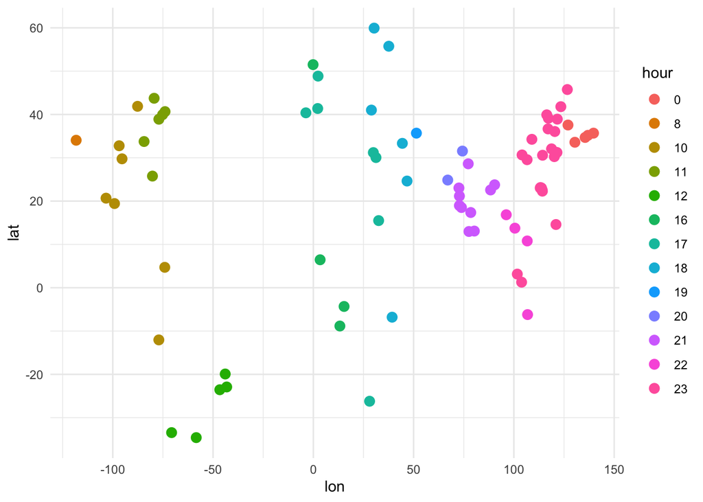

```r
output %>%
  mutate(hour = factor(hour)) %>%
  ggplot(aes(lon, lat)) +
    geom_point(aes(color = hour), size = 3)
```

### XKCD

As a second task for today, let’s create a data set from the API for the popular web comic XKCD. The API has a slightly different structure because the information about the kind of data we want to grab is stored in the path rather than the query parameters. To get the URL for the 10th comic from XKCD, for example, we need this code:

```r
i <- 10
url_str <- modify_url(sprintf("https://xkcd.com/%d/info.0.json", i))
```

In the following code, create a data set with all of the metadata for the first 25 XKCD comics. Make sure to grab all of the fields in the data.

```r
n <- 25
output <- vector("list", length = n)

for (i in seq_len(n))
{
  url_str <- modify_url(sprintf("https://xkcd.com/%d/info.0.json", i))
  res <- http_cache_get(url_str, cache_dir = "cache")

  stop_for_status(res)

  obj <- content(res, type = "application/json")
  output[[i]] <- tibble(
    month = obj$month,
    num = obj$num,
    link = obj$link,
    year = obj$year,
    news = obj$news,
    safe_title = obj$safe_title,
    transcript = obj$transcript,
    alt = obj$alt,
    img = obj$img,
    title = obj$title,
    day = obj$day
  )
}

output <- bind_rows(output)
output
```

```
## # A tibble: 25 × 11
##    month   num link  year  news  safe_title  transcript   alt     img    title  day
##    <chr> <int> <chr> <chr> <chr> <chr>       <chr>        <chr>   <chr>  <chr>  <chr>
##  1 1         1 ""    2006  ""    Barrel - P… "[[A boy si… Don't … https… Barre… 1
##  2 1         2 ""    2006  ""    Petit Tree… "[[Two tree… 'Petit… https… Petit… 1
##  3 1         3 ""    2006  ""    Island (sk… "[[A sketch… Hello,… https… Islan… 1
##  4 1         4 ""    2006  ""    Landscape … "[[A sketch… There'… https… Lands… 1
##  5 1         5 ""    2006  ""    Blown apart "[[A black … Blown … https… Blown… 1
##  6 1         6 ""    2006  ""    Irony       "Narrator: … It's c… https… Irony  1
##  7 1         7 ""    2006  ""    Girl sleep… "[[Girl sle… I don'… https… Girl … 1
##  8 1         8 ""    2006  ""    Red spiders "[[Many red… They a… https… Red s… 1
##  9 1         9 ""    2006  ""    Serenity i… "[[Several … Mal, S… https… Seren… 1
## 10 1        10 ""    2006  ""    Pi Equals   "Pi = 3.141… My mos… https… Pi Eq… 1
## # … with 15 more rows
```

Note that it should be trivial to adjust your code to get all of the comics as long as you know the number of the most recent comic. We are stopping at 25 to reduce our load on their servers and also to avoid a long run time in class.

### Qu’ran Cycle

Return to the API we used in notebook14 to grab the text from the Qu’ran. Create a data set that has one row for each ayah (verse) from the first 10 surah (chapters). The data only needs three columns: an id for the surah, an id for the ayah, and a column containing the actual text. You’ll need to use a similar technique to the XKCD example above.

```r
n <- 10
output <- vector("list", length = n)

for (i in seq_len(n))
{
  url_str <- modify_url(sprintf("http://api.alquran.cloud/v1/surah/%d/en.asad", i))
  res <- http_cache_get(url_str, cache_dir = "cache")

  stop_for_status(res)

  obj <- content(res, type = "application/json")
  output[[i]] <- tibble(
    surah = obj$data$number,
    ayah = map_int(obj$data$ayahs, ~ .x$number),
    text = map_chr(obj$data$ayahs, ~ .x$text)
  )
}

output <- bind_rows(output)
output
```

```
## # A tibble: 1,473 × 3
##    surah  ayah text
##    <int> <int> <chr>
##  1     1     1 In the name of God, The Most Gracious, The Dispenser of Grace:
##  2     1     2 All praise is due to God alone, the Sustainer of all the worlds,
##  3     1     3 The Most Gracious, the Dispenser of Grace,
##  4     1     4 Lord of the Day of Judgment!
##  5     1     5 Thee alone do we worship; and unto Thee alone do we turn for aid.
##  6     1     6 Guide us the straight way.
##  7     1     7 The way of those upon whom Thou hast bestowed Thy blessings, not of t…
##  8     2     8 Alif. Lam. Mim.
##  9     2     9 THIS DIVINE WRIT - let there be no doubt about it is [meant to be] a …
## 10     2    10 Who believe in [the existence of] that which is beyond the reach of h…
## # … with 1,463 more rows
```

We will use a version of this data set in the next class.